# Assignment2

Irene Fernández Rebollo i Àlex Martorell i Locascio

5/12/2021

# Presentation

A company which is active in Big Data and Data Science wants to hire data scientists among people who successfully pass some courses which are conducted by the company. Many people signup for their training. Company wants to know which of these candidates really want to work for the company after training or looking for a new employment because it helps to reduce the cost and time as well as the quality of training or planning the courses and categorization of candidates. Information related to demographics, education, experience are in hands from candidates signup and enrollment.

This dataset designed to understand the factors that lead a person to leave current job for HR researches too. By model(s) that uses the current credentials, demographics, experience data you will predict the probability of a candidate to look for a new job or will work for the company, as well as interpreting affected factors on employee decision.

# Data Preparation

```r
df <- read.csv("aug_train.csv",header=T, sep=",", na.strings="NA")
summary(df)
```

```
##   enrollee_id        city           city_development_index    gender
##  Min.   :    1   Length:19158       Min.   :0.4480         Length:19158
##  1st Qu.: 8554   Class :character   1st Qu.:0.7400         Class :character
##  Median :16983   Mode  :character   Median :0.9030         Mode  :character
##  Mean   :16875                      Mean   :0.8288
##  3rd Qu.:25170                      3rd Qu.:0.9200
##  Max.   :33380                      Max.   :0.9490
##  relevent_experience enrolled_university education_level    major_discipline
##  Length:19158        Length:19158        Length:19158       Length:19158
##  Class :character    Class :character    Class :character   Class :character
##  Mode  :character    Mode  :character    Mode  :character   Mode  :character
##
##
##
##   experience        company_size       company_type       last_new_job
##  Length:19158       Length:19158       Length:19158       Length:19158
##  Class :character   Class :character   Class :character   Class :character
##  Mode  :character   Mode  :character   Mode  :character   Mode  :character
##
##
##
##  training_hours       target
##  Min.   :  1.00   Min.   :0.0000
##  1st Qu.: 23.00   1st Qu.:0.0000
##  Median : 47.00   Median :0.0000
##  Mean   : 65.37   Mean   :0.2493
##  3rd Qu.: 88.00   3rd Qu.:0.0000
##  Max.   :336.00   Max.   :1.0000
```

## Removing Duplicates and Irrelavant Observations

```r
df <- unique(df)
nrow(df) == nrow(unique(df)) #No duplicates
```

```
## [1] TRUE
```

```r
# Use birthday of 1 member of the group as random seed:
set.seed(130798)
# Only take a subset of 5000 observations
samples <- as.vector(sort(sample(1:nrow(df),5000)))
df <- df[samples,]
```

## Fix structural errors

For coding purposes, blanks ("") in the dataframe are considered as NA’s.

```r
sum(is.na(df)) #0
```

```
## [1] 0
```

```r
df[df==""] <- NA
sum(is.na(df)) #5433
```

```
## [1] 5433
```

Some inconsistencies are also checked and corrected.

```r
# Column name relevent_experience should be relevant_experience
colnames(df)[5] <- "relevant_experience"
# Also their values should be with the "relevant" word
df$relevant_experience <- gsub("relevent", "relevant", df$relevant_experience)

# Correct the format of the company size
df$company_size[df$company_size == "10/49"] <- "10-49"
```

## Univariate Descriptive Analysis

### City code

```r
#head(df$city)
#length(unique(df$city)) #117
#nrow(df[is.na(df$city),]) #0

class(df$city) #"character"
```

```
## [1] "character"
```

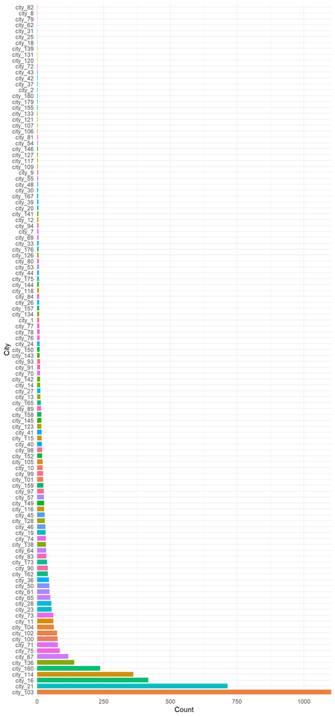

```r
df$city <- factor(df$city) #Transform to "factor"

ggplot(df,aes(x = forcats::fct_infreq(city), fill = city)) +
    geom_bar(stat = 'count', width = 0.8) +
    coord_flip() +
  scale_y_continuous(expand = c(0, 0)) +
  xlab("City") + ylab("Count") +
  scale_fill_discrete(guide = "none") +
  theme_minimal()
```

### Developement index of the city

```r
#head(df$city_development_index)
#length(unique(df$city_development_index)) #89
#nrow(df[is.na(df$city_development_index),]) #0

class(df$city_development_index) #"numeric"
```

```
## [1] "numeric"
```

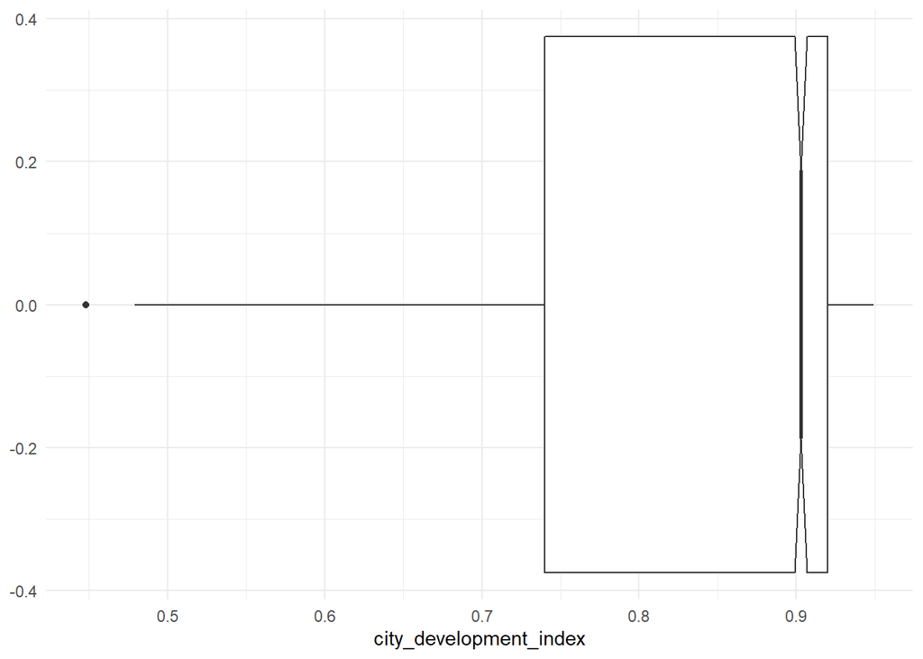

```r
# Kept as "numeric"

ggplot(df, aes(x = city_development_index)) +
  geom_boxplot(notch = TRUE) +
  theme_minimal()
```

### Gender of candidate

```r
#head(df$gender)
#length(unique(df$gender)) #4
#nrow(df[is.na(df$gender),]) #1184

class(df$gender) #"character"
```

```
## [1] "character"
```

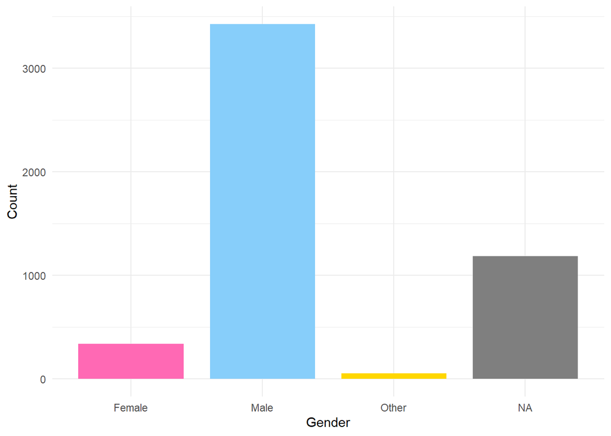

```r
df$gender <- factor(df$gender) #Transform to "factor"

ggplot(df,aes(x = gender, fill = gender)) +
    geom_bar(stat = 'count', width = 0.8) +
  scale_fill_manual(values = c("hotpink", "lightskyblue", "gold"), guide = "none") +
  xlab("Gender") + ylab("Count") +
  theme_minimal()
```

### Relevant experience of candidate

```r
#head(df$relevant_experience)
#length(unique(df$relevant_experience)) #2
#nrow(df[is.na(df$relevant_experience),]) #0

class(df$relevant_experience) #"character"
```

```
## [1] "character"
```

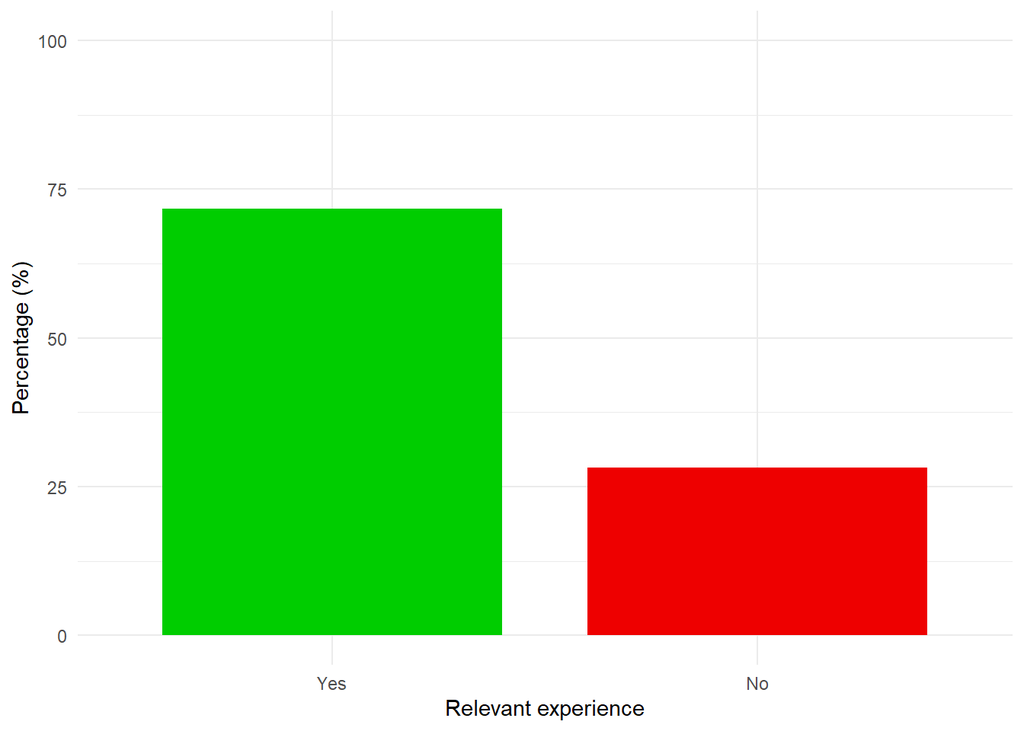

```r
df$relevant_experience <- factor(df$relevant_experience,
                                 levels=c("Has relevant experience", "No relevant experience"),
                                 labels = c("Yes", "No")) #Transform to "factor" and change to simpler values

ggplot(df,aes(x = relevant_experience, fill = relevant_experience)) +
    geom_bar(aes(y = (..count..)/sum(..count..)*100), width = 0.8) +
  scale_fill_manual(values = c("green3", "red2"), guide = "none") +
  xlab("Relevant experience") + ylab("Percentage (%)") + ylim(c(0, 100)) +
  theme_minimal()
```

### Type of University course enrolled

```r
#head(df$enrolled_university)
#length(unique(df$enrolled_university)) #4
#nrow(df[is.na(df$enrolled_university),]) #93

class(df$enrolled_university) #"character"
```

```
## [1] "character"
```

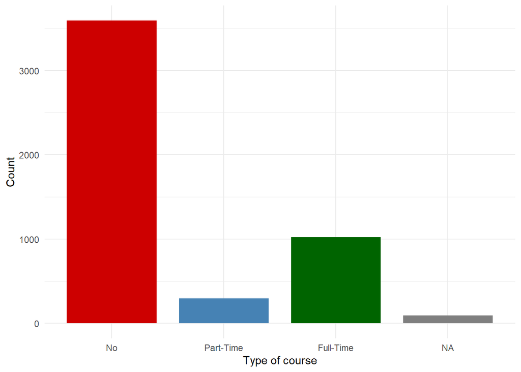

```r
df$enrolled_university <- factor(df$enrolled_university,
                                levels=c("no_enrollment", "Part time course", "Full time course"),
                                labels= c("No", "Part-Time", "Full-Time")) #Transform to "factor" and change to simpler values

ggplot(df,aes(x = enrolled_university, fill = enrolled_university)) +
    geom_bar(stat = 'count', width = 0.8) +
  scale_fill_manual(values  = c("red3", "steelblue", "darkgreen"), guide = "none") +
  xlab("Type of course") + ylab("Count") +
  theme_minimal()
```

### Education level of candidate

```r
#head(df$education_level)
#length(unique(df$education_level)) #6
#nrow(df[is.na(df$education_level),]) #115

class(df$education_level) #"character"
```

```
## [1] "character"
```

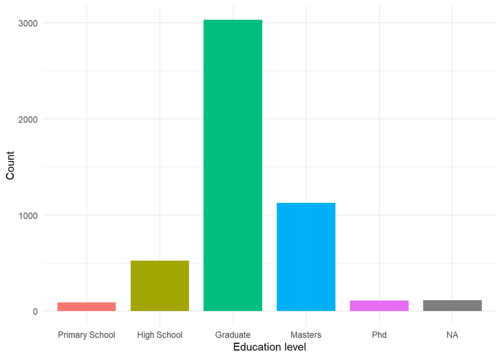

```r
df$education_level <- factor(df$education_level,
                            levels = c("Primary School", "High School",
                                      "Graduate", "Masters", "Phd")) #Transform to "factor"

ggplot(df,aes(x = education_level, fill = education_level)) +
    geom_bar(stat = 'count', width = 0.8) +
  scale_fill_discrete(guide = "none") +
  xlab("Education level") + ylab("Count") +
  theme_minimal()
```

### Education major discipline of candidate

```r
#head(df$major_discipline)
#length(unique(df$major_discipline)) #7
#nrow(df[is.na(df$major_discipline),]) #735

class(df$major_discipline) #"character"
```

```
## [1] "character"
```

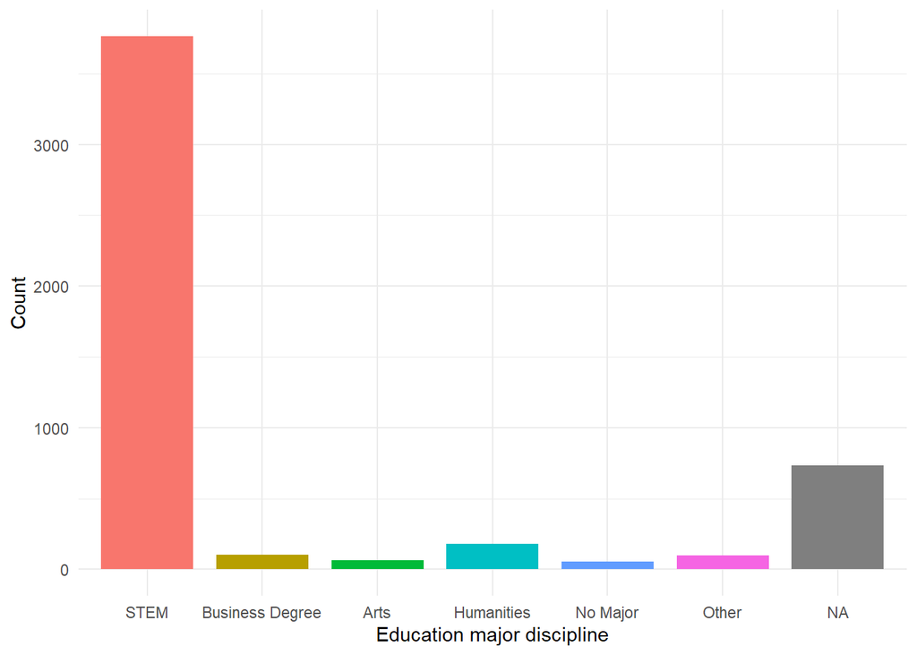

```r
df$major_discipline <-factor(df$major_discipline,
                             levels=c("STEM", "Business Degree", "Arts",
                                      "Humanities", "No Major", "Other")) #Transform to "factor"

ggplot(df,aes(x = major_discipline, fill = major_discipline)) +
    geom_bar(stat = 'count', width = 0.8) +
  xlab("Education major discipline") + ylab("Count") +
  scale_fill_discrete(guide = "none") +
  theme_minimal()
```

### Candidate total experience in years

```r
#head(df$experience)
#length(unique(df$experience)) #23
#nrow(df[is.na(df$experience),]) #16

class(df$experience) #"character"
```

```
## [1] "character"
```

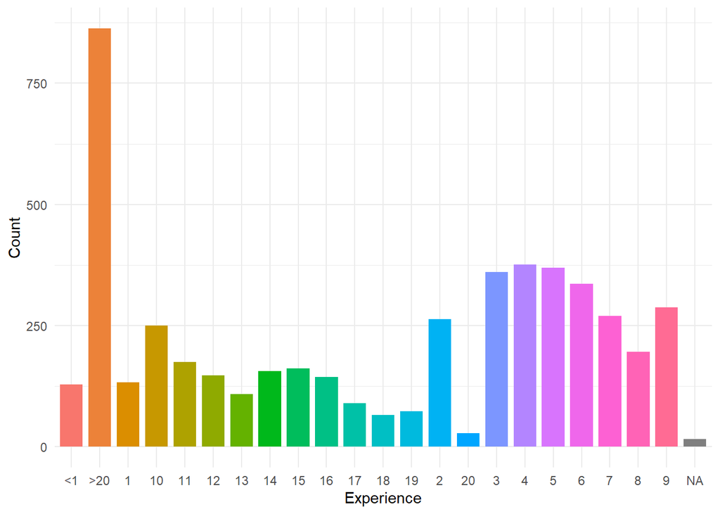

```r
df$experience <- factor(df$experience) #Transform to "factor"

#FACTOR, NUMERIC OR BOTH ?
#df$experience <- factor(df$experience)
#levels(df$experience) <- gsub("<1", "0", levels(df$experience))
#levels(df$experience) <- gsub(">20", "21", levels(df$experience))
#df$experience <- as.numeric(as.character(df$experience))
#df$experience_num <- df$experience
#intervals <- c(0 ,5 ,10 ,15 ,20, 25)
#df$experience <- factor(cut(df$experience,breaks=intervals, right=FALSE))

ggplot(df,aes(x = experience, fill = experience)) +
    geom_bar(stat = 'count', width = 0.8) +
  xlab("Experience") + ylab("Count") +
  scale_fill_discrete(guide = "none") +
  theme_minimal()
```

### Number of employees in current employer’s company

```r
#head(df$company_size)
#length(unique(df$company_size)) #9
#nrow(df[is.na(df$company_size),]) #1576

class(df$company_size) #"character"
```

```
## [1] "character"
```

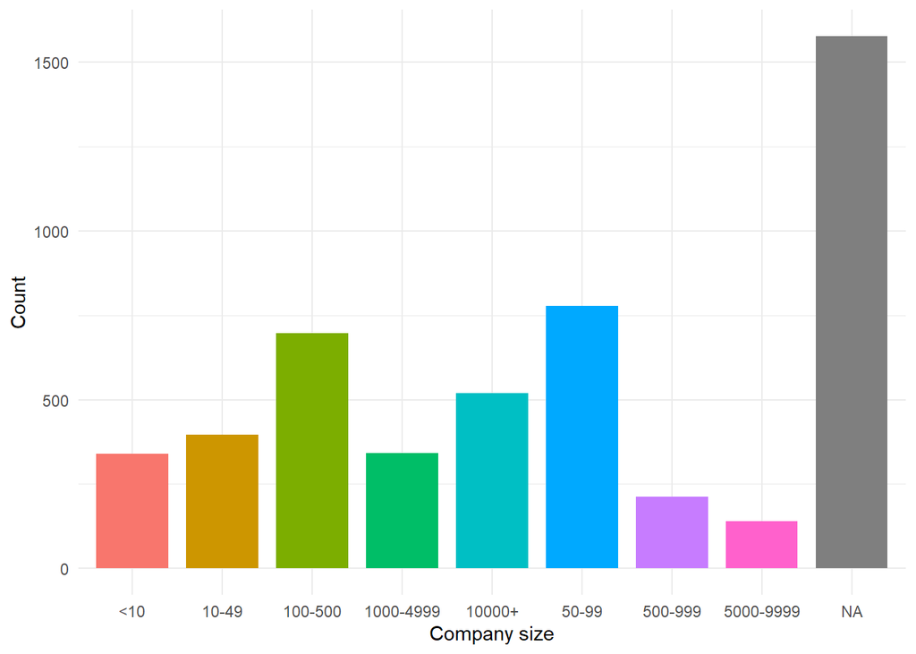

```r
df$company_size <- factor(df$company_size) #Transform to "factor"

ggplot(df,aes(x = company_size, fill = company_size)) +
    geom_bar(stat = 'count', width = 0.8) +
  xlab("Company size") + ylab("Count") +
  scale_fill_discrete(guide = "none") +
  theme_minimal()
```

### Type of current employer

```r
#head(df$company_type)
#length(unique(df$company_type)) #7
#nrow(df[is.na(df$company_type),]) #1608

class(df$company_type) #"character"
```

```
## [1] "character"
```

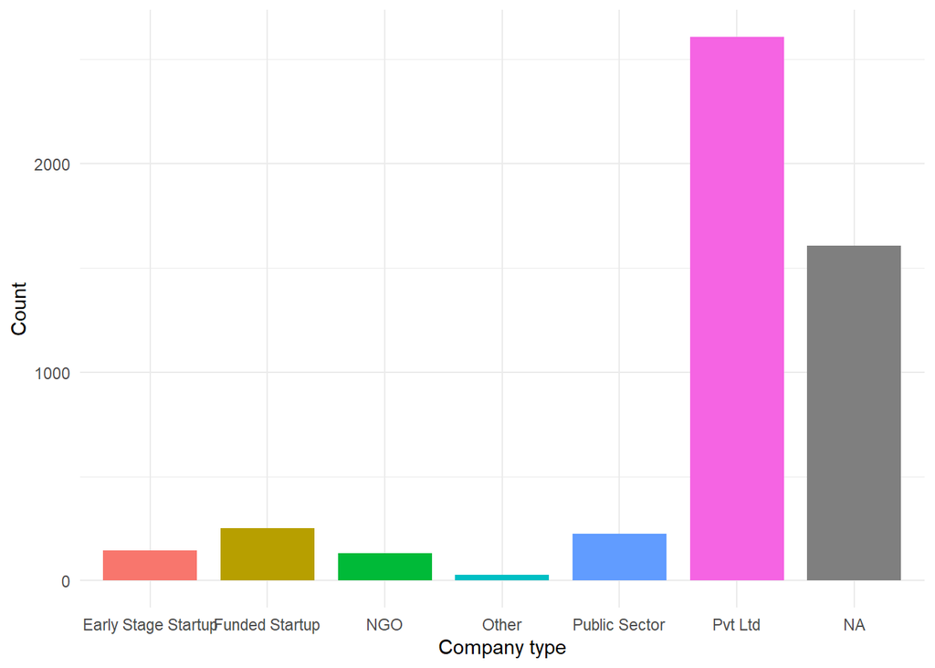

```r
df$company_type <- factor(df$company_type) #Transform to "factor"

ggplot(df,aes(x = company_type, fill = company_type)) +
    geom_bar(stat = 'count', width = 0.8) +
  xlab("Company type") + ylab("Count") +
  scale_fill_discrete(guide = "none") +
  theme_minimal()
```

### Difference in years between previous job and current job

```r
#head(df$last_new_job)
#length(unique(df$last_new_job)) #7
#nrow(df[is.na(df$last_new_job),]) #106

class(df$last_new_job) #"character"
```

```
## [1] "character"
```

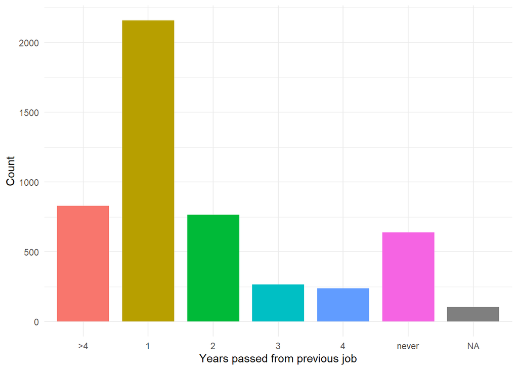

```r
df$last_new_job <-factor(df$last_new_job) #Transform to "factor"

ggplot(df,aes(x = last_new_job, fill = last_new_job)) +
    geom_bar(stat = 'count', width = 0.8) +
  xlab("Years passed from previous job") + ylab("Count") +
  scale_fill_discrete(guide = "none") +
  theme_minimal()
```

### Training hours completed

```r
#head(df$training_hours)
#length(unique(df$training_hours)) #237
#nrow(df[is.na(df$training_hours),]) #0

class(df$training_hours) #"integer"
```

```
## [1] "integer"
```

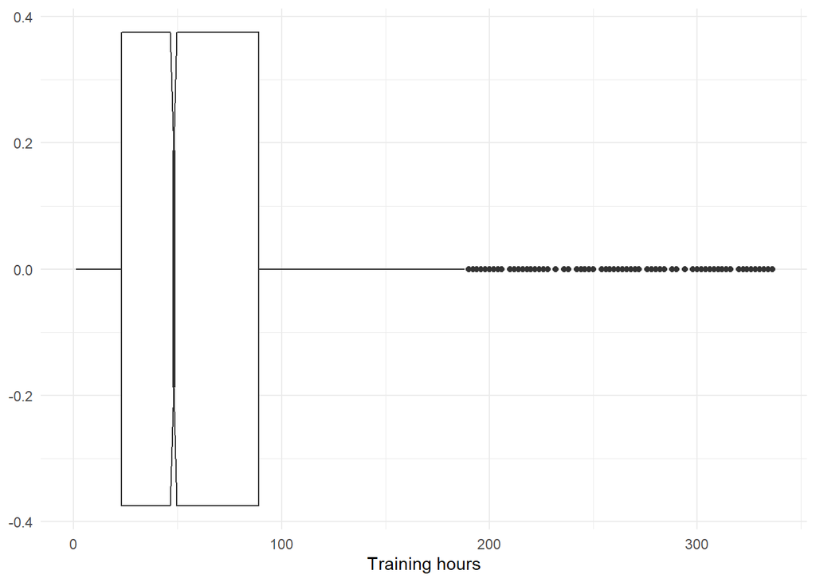

```r
#Keep as "integer"

ggplot(df,aes(x = training_hours)) +
    geom_boxplot(notch = TRUE) +
  xlab("Training hours")+
  theme_minimal()
```

## Missing values

The percentage of missing values per column with respect to their total varies significantly along different variables. \texttt{company_type} and \texttt{company_size} have over 30% of missing values. The numeric variables, the target, \texttt{relevant_experience}, and return no missing values.

```r
missing <- unlist(lapply(df, function(x) sum(is.na(x))))/nrow(df)
sort(missing[missing >= 0], decreasing = TRUE)
```

```
##           company_type           company_size                 gender
##                 0.3216                 0.3152                 0.2368
##       major_discipline        education_level           last_new_job
##                 0.1470                 0.0230                 0.0212
##    enrolled_university             experience            enrollee_id
##                 0.0186                 0.0032                 0.0000
##                   city city_development_index    relevant_experience
##                 0.0000                 0.0000                 0.0000
##         training_hours                 target
##                 0.0000                 0.0000
```

```r
sum(is.na(df[, 1:14]))
```

```
## [1] 5433
```

```r
count_na<-colSums(is.na(df[, 1:14]))
count_na
```

```
##            enrollee_id                   city city_development_index
##                      0                      0                      0
##                 gender    relevant_experience    enrolled_university
##                   1184                      0                     93
##        education_level       major_discipline             experience
##                    115                    735                     16
##           company_size           company_type           last_new_job
##                   1576                   1608                    106
##         training_hours                 target
##                      0                      0
```

```r
sum(is.na(df))
```

```
## [1] 5433
```

## Outliers

### Univariate Outlier detection

Outliers for the three numerical variables are considered. Training hours and city_development_index are fairly straightforward to analyze, but with regards to the experience variable there are no outliers due to the manner in which the variable was built. The characters “<1” and “>20” do not allow enough precision in order to identify for possible outliers, as they had to be converted to numbers 0 and 21 respectively during the conversion to a numeric variable (noting a significant bias).

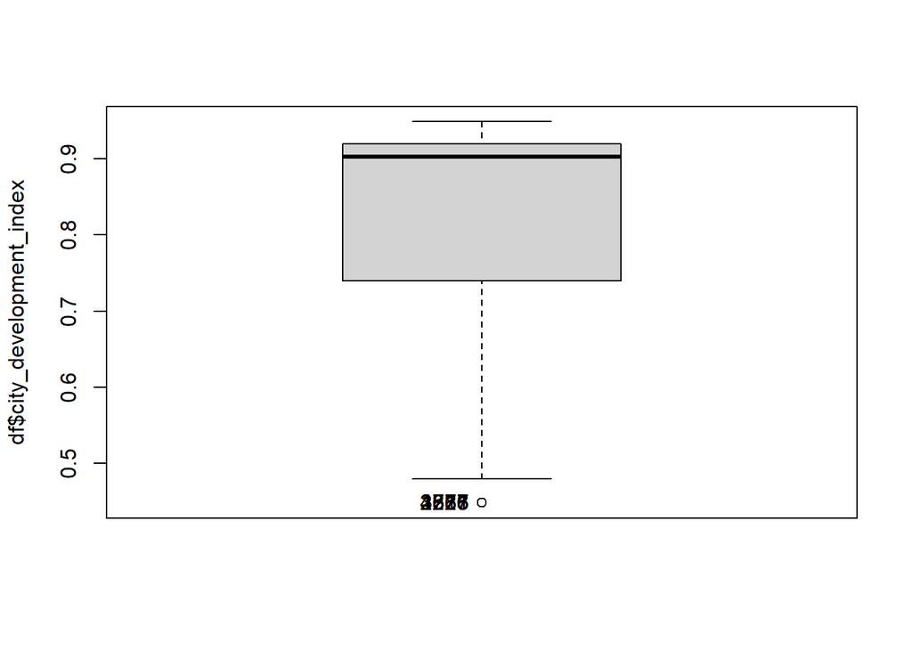

```
## [1] 1267 2376 2733 3518 3886 4621
```

```r
Boxplot(df$city_development_index)
```

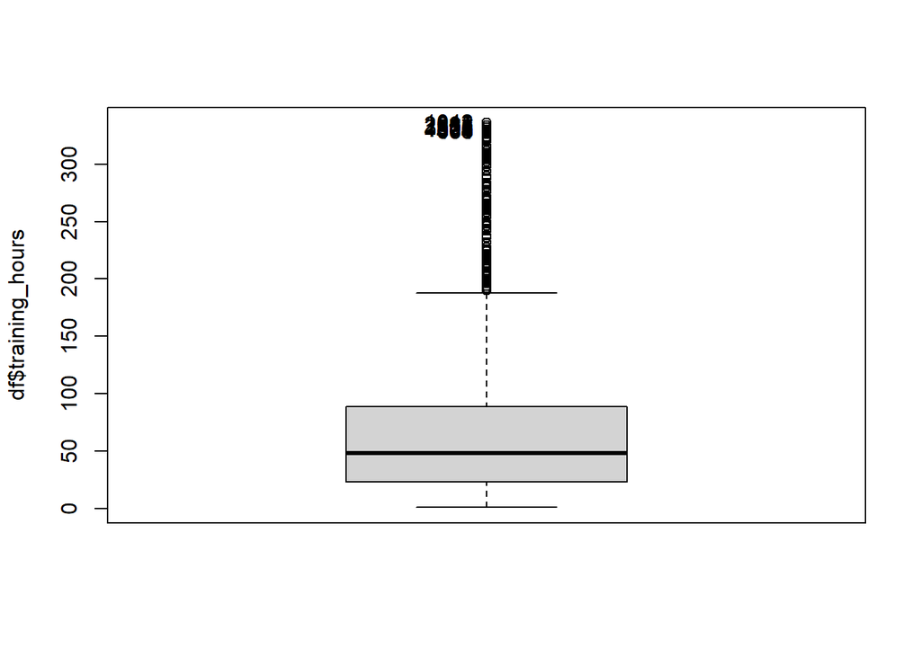

```
##  [1] 1042  811 2685  803 2387 3576 1304 4376  463  664
```

```r
Boxplot(df$training_hours)
```

```r
mout_city = quantile(df$city_development_index)[[2]]-1.5*IQR(df$city_development_index)
sum(df$city_development_index < mout_city)
```

```
## [1] 6
```

```r
mout_th = quantile(df$training_hours)[[4]]+1.5*IQR(df$training_hours)
eout_th = quantile(df$training_hours)[[4]]+3*IQR(df$training_hours)
sum(df$training_hours > mout_th)
```

```
## [1] 227
```

```r
sum(df$training_hours > eout_th)
```

```
## [1] 58
```

### Multivariate outlier detection

With the two numerical variables, we apply the Moutlier function at 99.5%. 105 multivariate outliers are returned.

```r
res.out<-Moutlier(df[,c(3,13)],quantile=0.995)
```

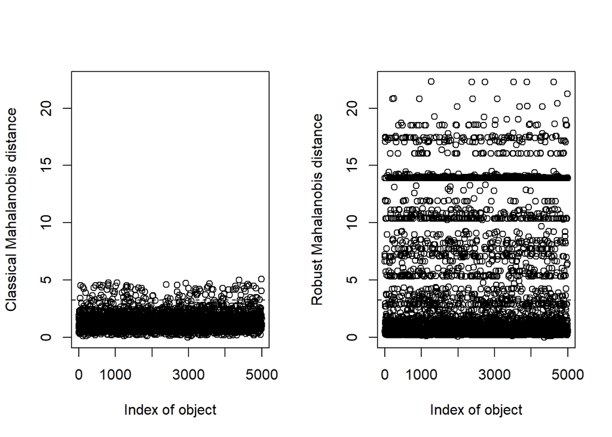

```r
str(res.out)
```

```
## List of 3
##  $ md    : Named num [1:5000] 1.091 0.872 1.782 1.928 0.425 ...
##   ..- attr(*, "names")= chr [1:5000] "5" "6" "15" "18" ...
##  $ rd    : Named num [1:5000] 7.08 7.22 13.89 13.89 6.66 ...
##   ..- attr(*, "names")= chr [1:5000] "5" "6" "15" "18" ...
##  $ cutoff: num 3.26
```

```r
res.out
```

[output not shown]

[output cut: 3049 more lines]

[output not shown]

```r
quantile(res.out$md,seq(0,1,0.005))
```

```
##       0.0%       0.5%       1.0%       1.5%       2.0%       2.5%       3.0%
## 0.01981397 0.21605973 0.28149843 0.32881836 0.39023886 0.43834195 0.46368468
##       3.5%       4.0%       4.5%       5.0%       5.5%       6.0%       6.5%
## 0.47917376 0.50815493 0.52074333 0.53937173 0.55389522 0.56240567 0.57585567
##       7.0%       7.5%       8.0%       8.5%       9.0%       9.5%      10.0%
## 0.59142843 0.60634276 0.62149227 0.63975289 0.65588179 0.66046402 0.66536173
##      10.5%      11.0%      11.5%      12.0%      12.5%      13.0%      13.5%
## 0.67106046 0.67811295 0.68996851 0.69652929 0.70625076 0.71693657 0.72641434
##      14.0%      14.5%      15.0%      15.5%      16.0%      16.5%      17.0%
## 0.73579622 0.73695658 0.73877667 0.74057319 0.74492220 0.74766885 0.75079154
##      17.5%      18.0%      18.5%      19.0%      19.5%      20.0%      20.5%
## 0.75186892 0.75428560 0.75814590 0.76236687 0.76694255 0.76945195 0.77186665
##      21.0%      21.5%      22.0%      22.5%      23.0%      23.5%      24.0%
## 0.77634084 0.77738962 0.78235477 0.78589186 0.78866181 0.79057236 0.79498093
##      24.5%      25.0%      25.5%      26.0%      26.5%      27.0%      27.5%
## 0.79827130 0.80147262 0.80555851 0.80833979 0.81139208 0.81529198 0.81679244
##      28.0%      28.5%      29.0%      29.5%      30.0%      30.5%      31.0%
## 0.82295913 0.82368534 0.82954625 0.83086687 0.83753467 0.83916973 0.84660943
##      31.5%      32.0%      32.5%      33.0%      33.5%      34.0%      34.5%
## 0.85105348 0.85469691 0.85912581 0.86559515 0.87333712 0.88150349 0.88438526
##      35.0%      35.5%      36.0%      36.5%      37.0%      37.5%      38.0%
## 0.89069509 0.89296889 0.89929616 0.90250798 0.91027945 0.91178490 0.92029349
##      38.5%      39.0%      39.5%      40.0%      40.5%      41.0%      41.5%
## 0.92343150 0.93222284 0.93861144 0.94275570 0.94866656 0.95347617 0.95705478
##      42.0%      42.5%      43.0%      43.5%      44.0%      44.5%      45.0%
## 0.96437799 0.96732609 0.97382335 0.97879470 0.98670153 0.99025505 0.99527642
##      45.5%      46.0%      46.5%      47.0%      47.5%      48.0%      48.5%
## 1.00125600 1.00463973 1.00967980 1.01420835 1.02140071 1.02470561 1.03058362
##      49.0%      49.5%      50.0%      50.5%      51.0%      51.5%      52.0%
## 1.03326914 1.03954492 1.04528007 1.04861398 1.05575688 1.05742865 1.06592314
##      52.5%      53.0%      53.5%      54.0%      54.5%      55.0%      55.5%
## 1.06810906 1.07284776 1.08014503 1.08264542 1.09148860 1.09465415 1.10204603
##      56.0%      56.5%      57.0%      57.5%      58.0%      58.5%      59.0%
## 1.10730801 1.11136289 1.11820188 1.12370633 1.13071665 1.13656421 1.14404129
##      59.5%      60.0%      60.5%      61.0%      61.5%      62.0%      62.5%
## 1.14596781 1.15345858 1.16002907 1.16570998 1.17223790 1.17966513 1.18553052
##      63.0%      63.5%      64.0%      64.5%      65.0%      65.5%      66.0%
## 1.19652789 1.20250648 1.21239569 1.22245240 1.22596209 1.23685268 1.24216596
##      66.5%      67.0%      67.5%      68.0%      68.5%      69.0%      69.5%
## 1.25334806 1.26133953 1.26716214 1.27901592 1.29167006 1.30506873 1.32384832
##      70.0%      70.5%      71.0%      71.5%      72.0%      72.5%      73.0%
## 1.34661157 1.36379375 1.38876653 1.41900564 1.44387031 1.46989772 1.49384257
##      73.5%      74.0%      74.5%      75.0%      75.5%      76.0%      76.5%
## 1.52475821 1.56870173 1.62378909 1.65136942 1.65301452 1.65775391 1.66079870
##      77.0%      77.5%      78.0%      78.5%      79.0%      79.5%      80.0%
## 1.66477854 1.66944340 1.67524164 1.68150021 1.69108941 1.69874162 1.70719521
##      80.5%      81.0%      81.5%      82.0%      82.5%      83.0%      83.5%
## 1.72096187 1.73058758 1.73726162 1.75216737 1.76388818 1.77627328 1.78999604
##      84.0%      84.5%      85.0%      85.5%      86.0%      86.5%      87.0%
## 1.80228345 1.81531456 1.82334576 1.83804167 1.84597226 1.86234998 1.87698130
##      87.5%      88.0%      88.5%      89.0%      89.5%      90.0%      90.5%
## 1.88513393 1.90179152 1.91050210 1.92989839 1.95447298 2.00288679 2.05740263
##      91.0%      91.5%      92.0%      92.5%      93.0%      93.5%      94.0%
## 2.11893116 2.17993702 2.23280154 2.27050174 2.29098864 2.33359368 2.38781009
##      94.5%      95.0%      95.5%      96.0%      96.5%      97.0%      97.5%
## 2.42920320 2.47286947 2.52507007 2.61555371 2.73901634 2.86434238 3.09581141
##      98.0%      98.5%      99.0%      99.5%     100.0%
## 3.34059784 3.67086896 4.06077360 4.39697302 5.10832919
```

```r
multout<-which(res.out$md > res.out$cutoff)
length(multout)
```

```
## [1] 105
```

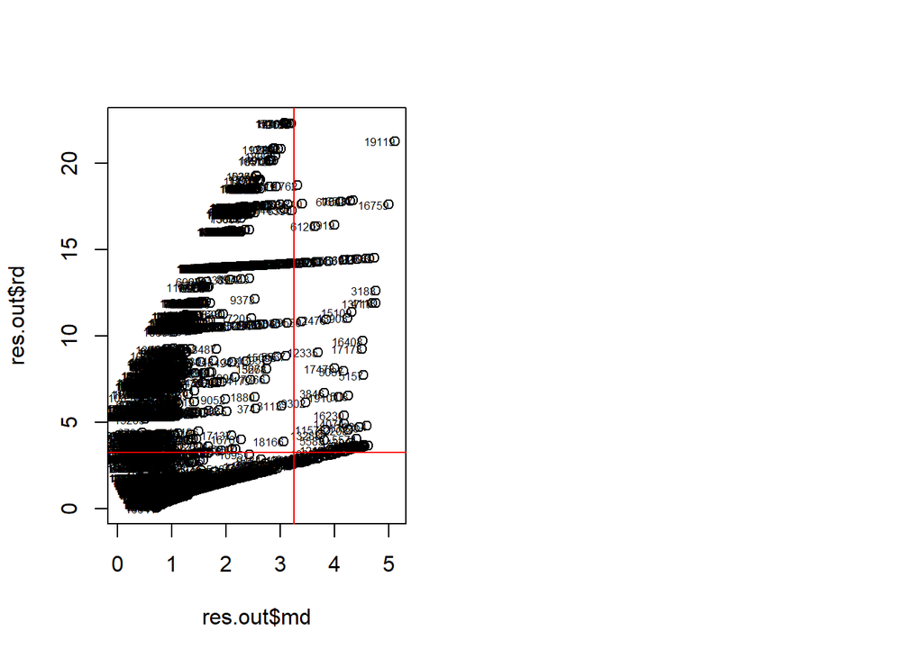

```r
plot( res.out$md, res.out$rd )
text(res.out$md, res.out$rd, labels=rownames(df),adj=1, cex=0.5)
abline(h=res.out$cutoff, col="red")
abline(v=res.out$cutoff, col="red")
```

```r
df$quality <-0
```

### Per variable

```r
dqvar <- data.frame(colnames(df[, 1:14]))
dqvar$outliers <-0
dqvar$missing <-0
dqvar$errors <-0

# Outliers
dqvar[13, "outliers"] <- sum(df$training_hours > mout_th) + sum(df$training_hours > eout_th)
dqvar[3, "outliers"] <- sum(df$city_development_index < mout_city)

#Missing
#We add missing values to the column per variable
dqvar$missing <- (colSums(is.na(df[, 1:14])))

dqvar
```

| colnames.df...1.14.. | outliers | missing | errors |
| --- | --- | --- | --- |
| enrollee_id | 0 | 0 | 0 |
| city | 0 | 0 | 0 |
| city_development_index | 6 | 0 | 0 |
| gender | 0 | 1184 | 0 |
| relevant_experience | 0 | 0 | 0 |
| enrolled_university | 0 | 93 | 0 |
| education_level | 0 | 115 | 0 |
| major_discipline | 0 | 735 | 0 |
| experience | 0 | 16 | 0 |
| company_size | 0 | 1576 | 0 |

[output cut: 4 more lines]

### Per individual

```r
dqind <- data.frame(df$enrollee_id)
colnames(dqind)[1] <- "enrollee_id"
dqind$missing <-0
dqind$outliers <-0
dqind$errors <-0

#Outliers
regmout_th <- subset(df$enrollee_id, df$training_hours > mout_th)
regeout_th <-subset(df$enrollee_id, df$training_hours > eout_th)
regmout_city <-subset(df$enrollee_id, df$city_development_index < mout_city)


for(i in 1:length(regmout_th)) {
  s<-which(df$enrollee_id == regmout_th[i])
  w<-which(dqind$enrollee_id == regmout_th[i])
  df[s, "quality"] <- df[s , "quality"] + 1
  dqind[w, "outliers"] <- dqind[w, "outliers"] + 1
}


for(i in 1:length(regeout_th)) {   # for-loop over rows
  s<-which(df$enrollee_id == regeout_th[i])
  w<-which(dqind$enrollee_id == regeout_th[i])
  df[s, "quality"] <- df[s , "quality"] + 1
  dqind[w, "outliers"] <- dqind[w, "outliers"] + 1
}

for(i in 1:length(regmout_city)) {   # for-loop over rows
  s<-which(df$enrollee_id == regmout_city[i])
  w<-which(dqind$enrollee_id == regmout_city[i])
  df[s , "quality"] <- df[s , "quality"] + 1
  dqind[w, "outliers"] <- dqind[w, "outliers"] + 1
}

df[multout, "quality"] <- df[multout, "quality"]+1
dqind[multout, "outliers"] <- dqind[multout, "outliers"] + 1

dqind$missing <- rowSums(is.na(df))
df$quality <- df$quality + rowSums(is.na(df))
head(dqind)
```

|  | enrollee_id | missing | outliers | errors |
| --- | --- | --- | --- | --- |
| 1 | 666 | 0 | 0 | 0 |
| 2 | 21651 | 3 | 0 | 0 |
| 3 | 8722 | 4 | 0 | 0 |
| 4 | 5764 | 1 | 0 | 0 |
| 5 | 7041 | 0 | 0 | 0 |
| 6 | 10408 | 0 | 0 | 0 |

Note that the quality variable is the sum of missing values and outliers. Using the package we obtain the correlation with the quantitative and qualitative variables. Note that company_size and company_type as factors seem to influence the most on the quality variable (R2 around 0.6). That is because of the large missing value number that these variables have.

```r
# Correlation
table(df$quality)
```

```
##
##    0    1    2    3    4    5    6    7    8
## 2171 1022 1000  545  178   54   23    4    3
```

```r
dqvar
```

| colnames.df...1.14.. | outliers | missing | errors |
| --- | --- | --- | --- |
| enrollee_id | 0 | 0 | 0 |
| city | 0 | 0 | 0 |
| city_development_index | 6 | 0 | 0 |
| gender | 0 | 1184 | 0 |
| relevant_experience | 0 | 0 | 0 |
| enrolled_university | 0 | 93 | 0 |
| education_level | 0 | 115 | 0 |
| major_discipline | 0 | 735 | 0 |
| experience | 0 | 16 | 0 |
| company_size | 0 | 1576 | 0 |

[output cut: 4 more lines]

```r
cor(df[, c(3, 13:15)])
```

```
##                        city_development_index training_hours      target
## city_development_index            1.000000000   -0.006019761 -0.32971376
## training_hours                   -0.006019761    1.000000000 -0.02210974
## target                           -0.329713763   -0.022109738  1.00000000
## quality                          -0.105990752    0.201059724  0.15757980
##                           quality
## city_development_index -0.1059908
## training_hours          0.2010597
## target                  0.1575798
## quality                 1.0000000
```

```r
res.con <- condes(df, 15)

res.con$quali
```

```
##                             R2       p.value
## education_level     0.29160790  0.000000e+00
## company_size        0.57934677  0.000000e+00
## company_type        0.57105470  0.000000e+00
## major_discipline    0.26162324 4.940656e-324
## last_new_job        0.19613276 2.362457e-232
## relevant_experience 0.17783188 8.198615e-215
## gender              0.16471079 1.284160e-194
## enrolled_university 0.13233214 2.088264e-153
## experience          0.09964441  9.313658e-97
## city                0.05151068  3.334249e-13
```

```r
res.con$quanti
```

```
##                        correlation      p.value
## training_hours           0.2010597 9.170131e-47
## target                   0.1575798 3.646471e-29
## city_development_index  -0.1059908 5.735764e-14
```

## Imputation of values

There are 14 variables and 5000 individuals; for each individual we can have from 0 to 7 NA’s along the variables. We can obtain an histogram were we can observe that there is a tail for higher number of missing values, so we determine a first rule of thumb that is that any row containing 5 missing values or more will be removed because of the cost that results when imputing so many values and only represents aprox. 1% of the samples.

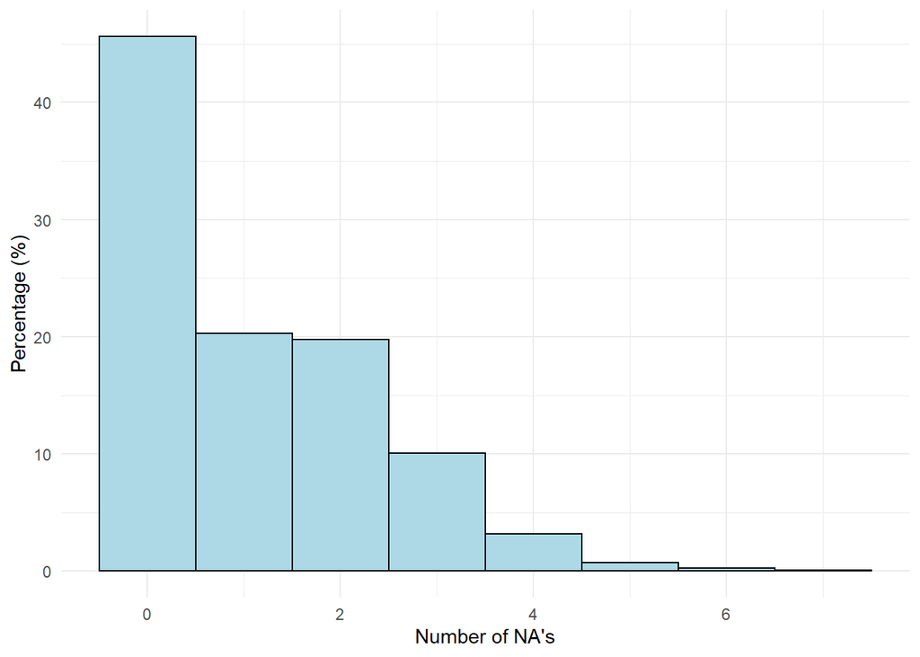

```r
#Create column with na counts for every observation
df$na_count <- rowSums(is.na(df))


# Actualitzem aquí el Data Quality per Missing's

for(i in 1:nrow(df)) {   # for-loop over rows
  df[i , "quality"] <- df[i , "quality"] + df[i, "na_count"]
  #w <- which(dqind$enrollee_id == df[i, "enrollee_id"])
  dqind[i, "missing"] <- df$na_count[i]
}



### AQUESTA VARIABLE S'HA DE CREAR A LA SECCIÓ ANTERIOR PERÒ PER PODER APLICAR LA IMPUTACIÓ LA HE CREAT AL PARTIR DELS NA'S ACTUALS SENSE TENIR EN COMPTE ELS OUTLIERS... ###

ggplot(df, aes(x = na_count, y = (..count..)/sum(..count..)*100)) +
  geom_histogram(binwidth = 1, color = "black", fill = "lightblue") +
  xlab("Number of NA's") + ylab("Percentage (%)") +
  theme_minimal()
```

```r
df <- df[df$na_count < 5,]
nrow(df) #4946
```

```
## [1] 4946
```

```r
100 - nrow(df)/5000*100 #only removed a 1.08% of the observations
```

```
## [1] 1.08
```

The variables with some NA value are: gender (1184), enrolled_university (93), education_level (115), major_discipline (735), experience (16), company_size (1576), company_type (1608), last_new_job (106). Each one is analysed separately to decide the required imputation method.

- Gender: In this case, there are a lot of NA’s. We decide to create a new category “Missing” because probably there are individuals that do not want to share this information.
- Enrolled university: In this case, we cannot assign a new category for NA’s since the variable stores already the three possible categories, so we decide to do imputation applying MCA.
- Education level: For this variable we also decide to impute NA’s with MCA because we cannot find any similarity of these values with the values of one category.
- Major discipline: Here the “STEM” category is more represented that the rest, so we try to collapse the rest in “Others” since the probabilities in the target are similar between them compared with the “STEM” value; following this approach, the NA’s were assigned into “Others”
- Experience: In experience, since we only have 10 missing values, we will use MCA imputation.
- Company size: There are a lot of NA’s in this variable, we create another category “Unknown” because is possible that the individual does not know this value.
- Company type: In this case, the number of missing values is very high. We tried to find some pattern in the probabilities of the categories in the target but the NA’s are very different from the rest. We decide to assign these NA’s values into the “Other” category because the number of individuals in the category are very low and does not make sense to create a “Missing” or “Unknown” category for this variable.
- Last new job: For this variable, analyzing the probabilities we saw some similarity with the category “4”, but as we are not sure of this assignation and the number of missing values not exceeds 100, we applied MCA imputation

```r
summary(df)
```

```
##   enrollee_id          city      city_development_index    gender
##  Min.   :    9   city_103:1096   Min.   :0.4480         Female: 338
##  1st Qu.: 8671   city_21 : 707   1st Qu.:0.7400         Male  :3419
##  Median :16980   city_16 : 415   Median :0.9030         Other :  52
##  Mean   :16875   city_114: 356   Mean   :0.8289         NA's  :1137
##  3rd Qu.:25044   city_160: 234   3rd Qu.:0.9200
##  Max.   :33375   city_136: 137   Max.   :0.9490
##                  (Other) :2001
##  relevant_experience enrolled_university       education_level
##  Yes:3574            No       :3572      Primary School:  88
##  No :1372            Part-Time: 294      High School   : 514
##                      Full-Time:1014      Graduate      :3030
##                      NA's     :  66      Masters       :1128
##                                          Phd           : 111
##                                          NA's          :  75
##
##         major_discipline   experience      company_size
##  STEM           :3762    >20    : 856   50-99    : 778
##  Business Degree: 102    4      : 372   100-500  : 695
##  Arts           :  64    5      : 364   10000+   : 519
##  Humanities     : 182    3      : 356   10-49    : 397
##  No Major       :  56    6      : 335   1000-4999: 341
##  Other          :  98    (Other):2653   (Other)  : 692
##  NA's           : 682    NA's   :  10   NA's     :1524
##               company_type  last_new_job training_hours       target
##  Early Stage Startup: 146   >4   : 824   Min.   :  1.00   Min.   :0.0000
##  Funded Startup     : 253   1    :2149   1st Qu.: 23.00   1st Qu.:0.0000
##  NGO                : 132   2    : 760   Median : 48.00   Median :0.0000
##  Other              :  29   3    : 265   Mean   : 64.81   Mean   :0.2406
##  Public Sector      : 224   4    : 238   3rd Qu.: 89.00   3rd Qu.:0.0000
##  Pvt Ltd            :2606   never: 619   Max.   :336.00   Max.   :1.0000
##  NA's               :1556   NA's :  91
##     quality          na_count
##  Min.   : 0.000   Min.   :0.000
##  1st Qu.: 0.000   1st Qu.:0.000
##  Median : 2.000   Median :1.000
##  Mean   : 2.158   Mean   :1.039
##  3rd Qu.: 4.000   3rd Qu.:2.000
##  Max.   :11.000   Max.   :4.000
##
```

```r
df$target <- factor(df$target, levels=c(1, 0), labels=c("Target.Yes", "Target.No"))
table(df$target)
```

```
##
## Target.Yes  Target.No
##       1190       3756
```

```r
#Gender
levels(df$gender)[length(levels(df$gender)) + 1] <- "Missing"
df[is.na(df$gender), "gender"] <- "Missing"

#Enrolled university
#levels(df$enrolled_university)[length(levels(df$enrolled_university)) + 1] <- "Missing"
#df[is.na(df$enrolled_university), "enrolled_university"] <- "Missing"
#prop.table(table(df$enrolled_university, df$target)) #missMDA
levels(df$enrolled_university)
```

```
## [1] "No"        "Part-Time" "Full-Time"
```

```r
nrow(df[is.na(df$enrolled_university),]) #66
```

```
## [1] 66
```

```r
#Education level
#levels(df$education_level)[length(levels(df$education_level)) + 1] <- "Missing"
#df[is.na(df$education_level), "education_level"] <- "Missing"
#prop.table(table(df$education_level, df$target)) #missMDA
levels(df$education_level)
```

```
## [1] "Primary School" "High School"    "Graduate"       "Masters"
## [5] "Phd"
```

```r
nrow(df[is.na(df$education_level),]) #75
```

```
## [1] 75
```

```r
#Major discipline
levels(df$major_discipline)[length(levels(df$major_discipline)) + 1] <- "Missing"
df[is.na(df$major_discipline), "major_discipline"] <- "Missing"
prop.table(table(df$major_discipline, df$target)) #STEM & other only?
```

```
##
##                    Target.Yes   Target.No
##   STEM            0.194702790 0.565911848
##   Business Degree 0.004245855 0.016376870
##   Arts            0.002224019 0.010715730
##   Humanities      0.006267691 0.030529721
##   No Major        0.002830570 0.008491710
##   Other           0.004852406 0.014961585
##   Missing         0.025475131 0.112414072
```

```r
df[df$major_discipline %in% c("Business Degree", "Arts", "Humanities", "No Major"), "major_discipline"] <- "Other"
table(df$major_discipline)
```

```
##
##            STEM Business Degree            Arts      Humanities        No Major
##            3762               0               0               0               0
##           Other         Missing
##             502             682
```

```r
prop.table(table(df$major_discipline, df$target)) #STEM & other only?
```

```
##
##                   Target.Yes  Target.No
##   STEM            0.19470279 0.56591185
##   Business Degree 0.00000000 0.00000000
##   Arts            0.00000000 0.00000000
##   Humanities      0.00000000 0.00000000
##   No Major        0.00000000 0.00000000
##   Other           0.02042054 0.08107562
##   Missing         0.02547513 0.11241407
```

```r
df[df$major_discipline == "Missing", "major_discipline"] <- "Other"
table(df$major_discipline)
```

```
##
##            STEM Business Degree            Arts      Humanities        No Major
##            3762               0               0               0               0
##           Other         Missing
##            1184               0
```

```r
prop.table(table(df$major_discipline, df$target)) #STEM & other only?
```

```
##
##                   Target.Yes  Target.No
##   STEM            0.19470279 0.56591185
##   Business Degree 0.00000000 0.00000000
##   Arts            0.00000000 0.00000000
##   Humanities      0.00000000 0.00000000
##   No Major        0.00000000 0.00000000
##   Other           0.04589567 0.19348969
##   Missing         0.00000000 0.00000000
```

```r
df$major_discipline <- factor(df$major_discipline)
levels(df$major_discipline)
```

```
## [1] "STEM"  "Other"
```

```r
#Experience
#levels(df$experience)[length(levels(df$experience)) + 1] <- "Missing"
#df[is.na(df$experience), "experience"] <- "Missing"
#prop.table(table(df$experience, df$target)) #missMDA
levels(df$experience)
```

```
##  [1] "<1"  ">20" "1"   "10"  "11"  "12"  "13"  "14"  "15"  "16"  "17"  "18"
## [13] "19"  "2"   "20"  "3"   "4"   "5"   "6"   "7"   "8"   "9"
```

```r
nrow(df[is.na(df$experience),]) #10
```

```
## [1] 10
```

```r
#Company size
levels(df$company_size)[length(levels(df$company_size)) + 1] <- "Unknown"
df[is.na(df$company_size), "company_size"] <- "Unknown"
prop.table(table(df$company_size, df$target)) #unknown
```

```
##
##              Target.Yes   Target.No
##   <10       0.012737566 0.055802669
##   10-49     0.017792155 0.062474727
##   100-500   0.021633643 0.118883947
##   1000-4999 0.009704812 0.059239790
##   10000+    0.017589972 0.087343308
##   50-99     0.030125354 0.127173474
##   500-999   0.005863324 0.037201779
##   5000-9999 0.005458957 0.022846745
##   Unknown   0.119692681 0.188435099
```

```r
#Company type
#levels(df$company_type)[length(levels(df$company_type)) + 1] <- "Missing"
#df[is.na(df$company_type), "company_type"] <- "Missing"
#prop.table(table(df$company_type, df$target)) #assign to other
df[is.na(df$company_type), "company_type"] <- "Other"

#Last new job
#levels(df$last_new_job)[length(levels(df$last_new_job)) + 1] <- "Missing"
#df[is.na(df$last_new_job), "last_new_job"] <- "Missing"
#prop.table(table(df$last_new_job, df$target)) #missMDA
levels(df$last_new_job)
```

```
## [1] ">4"    "1"     "2"     "3"     "4"     "never"
```

```r
nrow(df[is.na(df$last_new_job),]) #91
```

```
## [1] 91
```

```r
#library(missMDA)
#dfimp <- df
#colnames(dfimp)
#res <- MCA(dfimp[, c(4:12)])
#res <- MCA(dfimp[, c(6, 7, 9, 12)])
#vars_dis <- names(dfimp)[c(6, 7, 9, 12)]
#summary(dfimp[,vars_dis])
#nb <- estim_ncpMCA(dfimp[,vars_dis],ncp.max=25)
#res.input<-imputeMCA(dfimp[,vars_dis],ncp=10)

#Result of Imputation
#summary(res.input$completeObs)
#summary(df)
#df$enrolled_university <- res.input$completeObs$enrolled_university
#df$education_level <- res.input$completeObs$education_level
#df$experience <- res.input$completeObs$experience
#df$last_new_job <- res.input$completeObs$last_new_job
#summary(df)
#write.csv(df, "df_imputation.csv", row.names = FALSE)
```